# 03-analyze_03-v01.R

aelhabr

Sun Dec 10 17:01:58 2017

## “Specific” Questions

### Which individuals competed in the most competitions?

| rank | name | school | conf | cnt |
| --- | --- | --- | --- | --- |
| 1 | Jansa, Wade | Garden City | 1A | 57 |
| 2 | Chen, Kevin | Clements | 5A | 56 |
| 3 | Hanson, Dillon | Lindsay | 1A | 53 |
| 4 | Gee, John | Calhoun | 4A | 47 |
| 5 | Zhang, Mark | Clements | 5A | 47 |
| 6 | Robertson, Nick | Bridge City | 3A | 46 |
| 7 | Ryan, Alex | Klein | 5A | 46 |
| 8 | Strelke, Nick | Argyle | 3A | 45 |
| 9 | Niehues, Taylor | Garden City | 1A | 44 |
| 10 | Bass, Michael | Spring Hill | 3A | 43 |

There’s not too much to “learn” from this ranking by simple count of number of competitions competed in. All I can say is that I’m jealous of these people.

### From which conferences do the individuals who competed the most come?

| conf | cnt | rank |
| --- | --- | --- |
| 1A | 235 | 1 |
| 4A | 196 | 2 |
| 5A | 190 | 3 |
| 2A | 177 | 4 |
| 3A | 173 | 5 |
| 6A | 29 | 6 |

What stands out here is that there doesn’t seem to be as many individual competitors in `6A`. I would hypothesize that this might because the `6A` conference has the largest schools, which are more likely to “allocate sparingly” their individual competitors among different competitions. (There is a limit on the number of entrants per school in a given competition. Smaller schools are much less likely to ever have enough people to reach the per-school limit, so individuals at these schools are welcom to compete in as many competitions as they would like.)

### Which individuals were most “dominant”?

To rank the most “dominant” competitors, I use the sum of the percentile rank of placings in all competitions (i.e. `prank_sum`).

I use `prank_sum` (or some slight modification of it) as the primary choice for ranking individuals and schools in other parts of my analysis. (Raw `score` is also used, although it is “naive”.)

| name | school | conf | prank_mean | defeat_cnt_mean | prank_sum | defeat_cnt_sum | rank |
| --- | --- | --- | --- | --- | --- | --- | --- |
| Hanson, Dillon | Lindsay | 1A | 0.97 | 29 | 51 | 1546 | 1 |
| Chen, Kevin | Clements | 5A | 0.91 | 30 | 51 | 1668 | 2 |
| Jansa, Wade | Garden City | 1A | 0.89 | 30 | 51 | 1696 | 3 |
| Niehues, Taylor | Garden City | 1A | 0.96 | 31 | 42 | 1367 | 4 |
| Gee, John | Calhoun | 4A | 0.90 | 25 | 42 | 1185 | 5 |
| Strelke, Nick | Argyle | 3A | 0.93 | 27 | 42 | 1195 | 6 |
| Zhang, Mark | Clements | 5A | 0.89 | 29 | 42 | 1356 | 7 |
| Robertson, Nick | Bridge City | 3A | 0.88 | 25 | 41 | 1165 | 8 |
| Ryan, Alex | Klein | 5A | 0.86 | 26 | 39 | 1195 | 9 |
| Xu, Steven | Dawson | 4A | 0.88 | 27 | 38 | 1153 | 10 |

Somewhat suprisingly, some of the same individuals from the raw “counts” ranking of competitors also appeaer in the top of the ranks by my evaluation of domination. Some additional statistical analysis could be done here to investigate correlations.

### To what extent have some individual competitors “carried” their teams?

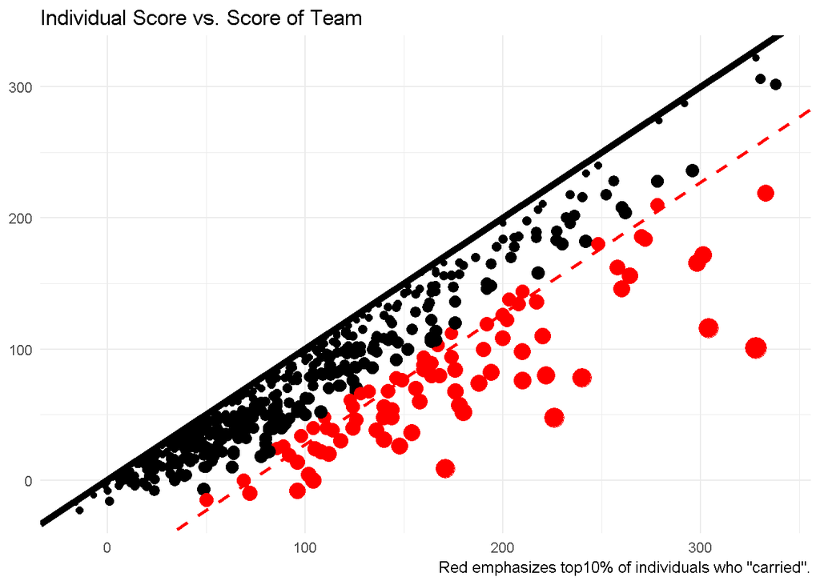

This visualization only provides a glimpse at what could be done to investigate this question. Anyways, I find it cool to see just how much some invidiuals “rise above” the rest of their team.

### Which siblings competed in the most competitions?

Being a twin, the performance of siblings (some of which are most definitiely twins) was something peculiar that I wanted to look at.

| rank | name_last | name_first_pair | cnt |
| --- | --- | --- | --- |
| 1 | Zhang | Jim & Mark | 24 |
| 2 | Ballard | Chance & Rance | 22 |
| 3 | Garcia | Javier & Juan | 20 |
| 4 | Walter | Collin & Lowell | 20 |
| 5 | Bass | Brian & Michael | 19 |
| 6 | Fabre | Guadalupe & Maria | 19 |
| 7 | Priest | Alex & Chandler | 18 |
| 8 | Vicuna | Bianca & Daniel | 17 |
| 9 | Gee | Grace & John | 16 |
| 10 | Morris | Jason & Ty | 16 |

I was dissapointed to find that my brother and I were not at the very top of this list. Nevertheless, we rank relatively well (we rank 18, having competed in 13 competitions together).

### Which siblings were the most “dominant”?

| rank | name_last | name_first_pair | sum |
| --- | --- | --- | --- |
| 1 | Zhang | Jim & Mark | 40 |
| 2 | Garcia | Javier & Juan | 35 |
| 3 | Ballard | Chance & Rance | 33 |
| 4 | Priest | Alex & Chandler | 32 |
| 5 | Fabre | Guadalupe & Maria | 30 |
| 6 | Walter | Collin & Lowell | 30 |
| 7 | Bass | Brian & Michael | 30 |
| 8 | Gee | Grace & John | 26 |
| 9 | Morris | Jason & Ty | 24 |
| 10 | Ochoa | Juan & Lidia | 23 |

It looks like these rankings are fairly similar. My brother and I are ranked 29, having aggregated a total percentile rank of 16.89 combined.

### How have people at my school performed?

Aside from just my brother and me, I was interested in looking at the perfromance of the people at my school. Although we weren’t the top performaning siblings, I was hoping to see us among the top of people at our school.

| rank | name | cnt | prank_sum | prank_mean | defeat_cnt |
| --- | --- | --- | --- | --- | --- |
| 714 | Land, Noah | 17 | 13.7 | 0.80 | 447 |
| 872 | Fulton, Chris | 18 | 12.7 | 0.70 | 351 |
| 939 | Gonzales, Gavyn | 17 | 12.3 | 0.72 | 371 |
| 1583 | Elhabr, Andrew | 15 | 9.9 | 0.66 | 296 |
| 2063 | Perry, Robert | 15 | 8.8 | 0.58 | 249 |
| 2490 | Garcia, Jon | 9 | 7.9 | 0.88 | 259 |
| 2494 | Nesser, Austin | 17 | 7.9 | 0.47 | 231 |
| 2611 | Elhabr, Anthony | 13 | 7.8 | 0.60 | 216 |
| 5182 | Guyott, David | 9 | 5.4 | 0.60 | 157 |
| 5256 | Baker, Ian | 10 | 5.3 | 0.53 | 185 |

Ranking by `prank_sum`, it looks like my brother and I *are* among the top performers in our school’s history.

### How has my school performed over time?

| rank | year | prank_sum | prank_mean | defeat_cnt | advanced_cnt | state_cnt |
| --- | --- | --- | --- | --- | --- | --- |
| 951 | 2007 | 6.3 | 0.79 | 40 | 3 | 0 |
| 1709 | 2014 | 5.0 | 0.63 | 31 | 3 | 0 |
| 2452 | 2006 | 4.2 | 0.53 | 14 | 3 | 0 |
| 2510 | 2005 | 4.2 | 0.59 | 13 | 2 | 0 |
| 3036 | 2011 | 3.7 | 0.75 | 22 | 1 | 0 |
| 3059 | 2017 | 3.7 | 0.53 | 25 | 2 | 0 |
| 3454 | 2012 | 3.4 | 0.57 | 19 | 1 | 0 |
| 5050 | 2015 | 2.6 | 0.44 | 12 | 1 | 0 |
| 5079 | 2016 | 2.6 | 0.52 | 13 | 0 | 0 |
| 5298 | 2013 | 2.5 | 0.62 | 15 | 0 | 0 |
| 5903 | 2010 | 2.3 | 0.45 | 12 | 1 | 0 |
| 7942 | 2008 | 1.6 | 0.39 | 11 | 0 | 0 |
| 9306 | 2009 | 1.2 | 0.29 | 6 | 0 | 0 |

Judging by `prank_sum`, it doesn’t look like my school has any consistent trend in performance by year. In some years my school did well, and in others… not so much. In fact, my school has *never* made an appearnce in a `State` competitions!

### Which schools have been the most “dominant”?

| rank | school | prank_sum | prank_mean | defeat_cnt | advanced_cnt | state_cnt |
| --- | --- | --- | --- | --- | --- | --- |
| 1 | Argyle | 159 | 0.95 | 867 | NA | 0 |
| 2 | Memorial | 156 | 0.49 | 887 | 50 | 0 |
| 3 | Clements | 149 | 0.86 | 932 | NA | 0 |
| 4 | Highland Park | 143 | 0.74 | 746 | NA | 0 |
| 5 | Wylie | 137 | 0.66 | 700 | NA | 0 |
| 6 | Lindsay | 134 | 0.87 | 791 | NA | 0 |
| 7 | Klein | 131 | 0.86 | 780 | NA | 0 |
| 8 | Dulles | 129 | 0.83 | 823 | NA | 0 |
| 9 | Liberty | 128 | 0.68 | 703 | NA | 0 |
| 10 | Coronado | 127 | 0.67 | 856 | NA | 0 |

I didn’t expect to see my school among the most “dominant” schools. Nevertheless, my school is ranked at 246, which is respectable.

# Conclusion

That’s all the analysis I’ll do for now. There is *SOOOO* much more that could be explored. Alas, I’ll leave that for another time.